# Chapter 11 - Integrative Analysis of Multi-Omics Data

Sasha Ajay Malkani

2026-01-14

## 1. Integrative Analysis of Multi-Omics Data

In the realm of bioinformatics, multi-omics data integration is becoming increasingly crucial for deriving comprehensive biological insights. The term “multi-omics” refers to the integration of various biological layers, such as genomics, transcriptomics, proteomics, and metabolomics, to better understand cellular processes and disease mechanisms. The synergistic approach of combining different omics data can help to unravel complex biological interactions and provide a more holistic view of cellular function.

This chapter will discuss the principles and methods associated with a specific focus on utilizing the R programming language. We will explore various R packages and libraries designed for multi-omics analysis, step-by-step methodologies for integration, and interpretative frameworks that can facilitate biological discoveries.

### 1. A. Understanding Multi-Omics Data.

Before we delve into the methods of analysis, it is essential to understand what constitutes multi-omics data and its implications in biological research. Multi- omics data sets include:

- **Genomics**: Information regarding DNA sequences, including mutations, single nucleotide polymorphisms (SNPs), and copy number variations(CNVs).
- **Transcriptomics**: Data about RNA expression levels which may involve RNA sequencing (RNA-seq) data or microarray data.
- **Proteomics**: The study of the entire set of proteins produced in an organism, tissue or cell, often analyzed through mass spectrometry.
- **Metabolomics**: The comprehensive profiling of metabolites in a biological sample which can reflect the biochemical activities associated with cellular processes.

Combining these different layers of biological information enables researchers to obtain a more enriched view of biological phenomena.

### 1. B. Preparation of Data for Analysis

#### 1. B. I. Data Acquisition.

The first step involves obtaining multi-omics datasets. This can be accomplished through various databases and repositories such as:

- **The National Center for Biotechnology Information (NCBI)**
- **The European Molecular Biology Laboratory (EMBL)**
- **European Bioinformatics Institute (EBI)**
- **The Gene Expression Omnibus (GEO)**
- **The Metabolomics Workbench**

#### 1. B. II. Data Preprocessing

Once the data is acquired, preprocessing is essential for ensuring the quality and compatibility of the datasets.

This may involve:

- Normalization of expression levels across datasets.
- Removal of batch effects using techniques such as ComBat or SVA (Surrogate Variable Analysis).
- Handling missing data through imputation or removal.

The “limma”, “DESeq2”, and “edgeR” packages in R can be employed for preprocessing transcriptomic data, while the “impute” package can help deal with missing values.

### 1. C. Integrative Analysis Methods

#### 1. C. I. Multimodal Integration Approaches

After preprocessing, the next step involves the integration of multi-omics data. Various approaches can be used, each with its own advantages depending on the data types and research questions:

- **Bayesian Networks**: These methods use probabilistic graphical methods to infer relationships across different omics layers.
- **Matrix Factorization**: Techniques such as Canonical Correlation Analysis (CCA) can be employed for integrating datasets in a lower-dimensional space.

#### 1. C. II. Network-Based Approches

Network-Based methods provide a visual representation of the interconnected relationships between genes, proteins and metabolites. Packages like “igraph” and “pathview” in R can be valuable here, allowing you to construct and visualize biological networks.

#### 1. C. III. Machine Learning

Machine Learning techniques can facilitate the integration of omic data by identifying patterns that may not be evident from a linear combination of the data. For instance, Random Forest or Support Vector Machines can classify data points based on integrated features from multiple omic levels. The “caret” and “mlr” packages are potent tools in R for these analyses.

### 1. D. Case Studies

#### 1. D. I. Case Study 1: Cancer Research

In cancer research, integrating genomic and transcriptomic data has been instrumental in discovering biomarkers for diagnosis, prognosis and treatment response. For example, using RNA-Seq data along with genomic variants can help identify mutations that lead to changes in gene expression associated with tumor progression.

#### 1. D. II. Case Study 2: Metabolic Disorders

For studies on metabolic disorders, metabolomics data combined with transcriptomics can reveal how changes in gene expression affect metabolic pathways.Using R, these integrative analyses can highlight critical pathways and potential therapeutic targets.

### 1. E. Visualization of Multi-Omics Data

Visualization plays a significant role in multi-omics data analysis. By using R packages such as “ggplot2”, “ComplexHeatmap”, and “pheatmap”, researchers can create informative visual representations of data integration results, allowing for easier interpretation and communication of findings.

### 1. F. Challenges and Future Directions

While multi-omics analysis offers tremendous potential, several challenges still several challenges still need to be addressed. These include high dimensionality, data heterogeneity and complexities in integrating data from disparate sources.

Future developments in R and bioinformatics tools should focus on enhancing integrative capabilities, improving user-friendliness, and providing robust statistical frameworks for better interpretability.

The integrative analysis of multi-omics data is a powerful approach in bioinformatics that enhances our understanding of biological systems. Utilizing R for this purpose enables researchers to leverage a wide range of packages and methodologies tailored for multi-omics integration. As technology matures and more data become available, the insights garnered from these analyses will undoubtedly lead to significant breakthroughs in personalized medicine, biotechnology, and systems biology.

## 2. Combining Transcriptomics, Proteomics and Metabolomics

Each of these layers offers unique insights into the regulatory mechanisms governing cellular function, but it is their integration that can reveal a more holistic view of biological phenomena. This chapter will provide an overiew of how to combine these three “-omics” data types in R, leveraging the statistical power and flexibility of R packages designed for these purposes.

### 2. A. Overview of Omics Technologies

Before delving into the integration methodologies, it is essential to understand the basics of each omics technology:

- **Transcriptomics**: The study of RNA transcripts produced by the genome, which provides insights into gene expression levels. **High-throughput sequencing technologies (RNA-seq)** have revolutionized the field by providing extensive data on mRNA abundance across various conditions.
- **Proteomics**: The large-scale study of proteins, particularly their structures and functions. **Mass spectrometry (MS)** is widely used technique in proteomics for quantifying proteins and identifying post-translational modifications.
- **Metabolomics**: The analysis of metabolites, which are small molecules produced during metabolic processes. Metabolomics provides a snapshot of the biochemical activity of cells and is often analyzed using techniques such as **nuclear magnetic resonance (NMR) spectroscopy** and **mass spectrometry (MS)**.

### 2. B. Data Acquistion and Preprocessing.

#### 2. B. I. Importing Data into R.

For this titorial, we will assume you have already generated and preprocessed your transcriptomics, proteomics and metabolomics data. Depending on your experimental design, you might have these datasets in formats such as CSV, Excel, or specific data formats like FASTA or mzML. Below are snoppets for loading each data type into R.

```r
# Load required libraries
library(tidyverse)
library(readr)

# For read_csv()
library(reshape2) # For melt()
# Load transcriptomics data
# transcriptomics_data <- read_csv("")

# Data Acquisition from GEO repository

# Install and load necessary packages
# install.packages("BiocManager")
# BiocManager::install("GEOquery")
library(GEOquery)
library(Biobase)

# Load GEO dataset
geo_dataset <- getGEO("GSE57820", GSEMatrix = TRUE)
```

```
## Found 1 file(s)
## GSE57820_series_matrix.txt.gz
```

```r
ls()
```

```
## [1] "geo_dataset"
```

```r
# Re-assign dataset name to something shorter
geo = geo_dataset
geo
```

```
## $GSE57820_series_matrix.txt.gz
## ExpressionSet (storageMode: lockedEnvironment)
## assayData: 47323 features, 12 samples
##   element names: exprs
## protocolData: none
## phenoData
##   sampleNames: GSM1394594 GSM1394595 ... GSM1394605 (12 total)
##   varLabels: title geo_accession ... transfected with:ch1 (45 total)
##   varMetadata: labelDescription
## featureData
##   featureNames: ILMN_1343291 ILMN_1343295 ... ILMN_3311190 (47323
##     total)
##   fvarLabels: ID Species ... GB_ACC (30 total)
##   fvarMetadata: Column Description labelDescription
## experimentData: use 'experimentData(object)'
##   pubMedIds: 25907805
## Annotation: GPL10558
```

```r
# Title of study
geo[["GSE57820_series_matrix.txt.gz"]]@experimentData@title
```

```
## [1] "The effect of miRNA-135b overexpression on the gene expression profile of LNCaP cells"
```

```r
# Abstract
geo[["GSE57820_series_matrix.txt.gz"]]@experimentData@abstract
```

```
## [1] "MicroRNAs (miRNAs) regulate a wide range of cellular signaling pathways and biological processes in both physiological and pathological states such as cancer. We have previously identified miR-135b as a direct regulator of androgen receptor (AR) protein level in prostate cancer (PCa). We wan…
```

```r
# Split geo_dataset into pdata, fdata and expression data
pdata_geo=geo[["GSE57820_series_matrix.txt.gz"]]@phenoData
head(pdata_geo, n = 1)
```

```
## An object of class 'AnnotatedDataFrame'
##   sampleNames: GSM1394594
##   varLabels: title geo_accession ... transfected with:ch1 (45 total)
##   varMetadata: labelDescription
```

```r
pdata_geo <- pData(pdata_geo)
head(pdata_geo, n = 1)
```

[output not shown]

```r
fdata_geo = geo[["GSE57820_series_matrix.txt.gz"]]@featureData
head(fdata_geo, n = 1)
```

```
## An object of class 'AnnotatedDataFrame'
##   featureNames: ILMN_1343291
##   varLabels: ID Species ... GB_ACC (30 total)
##   varMetadata: Column Description labelDescription
```

```r
expression_data = geo[["GSE57820_series_matrix.txt.gz"]]@assayData[["exprs"]]
head(expression_data, n = 1)
```

```
##              GSM1394594 GSM1394595 GSM1394596 GSM1394597 GSM1394598 GSM1394599
## ILMN_1343291   14.89197   14.84957   14.83455   14.91057   14.91057   14.80127
##              GSM1394600 GSM1394601 GSM1394602 GSM1394603 GSM1394604 GSM1394605
## ILMN_1343291   14.92433   14.84957   14.93193   14.89599   14.83455    14.8525
```

```r
# Re-assign expression_data matrix to transcript-omics data
transcriptomics_data <- expression_data

# Load proteomics data
# proteomics_data <- read_csv("")

# Load metabolomics data
# metabolomics_data <- read_csv("")
```

#### 2. B. II. Data Cleaning and Normalization

In most cases, raw data will require normalization and quality control. Here’s a brief outline of the common normalization techniques:

- **Transcriptomics**: Normalization can be done using methods like **Trimmed Mean of M-values (TMM)** or **Quantile normalization** depending on the platform.
- **Proteomics**: Techniques like **total ion current normalization** or use of **reference proteins** can be employed.
- **Metabolomics**: Normalization can include **log transformation**, **quantile normalization** or **scaling**. Here’s how you might normalize transcripomics data with the “edgeR” package:

```r
# Load Library
library(edgeR)
# Create DGEList object
transcriptomics_data <- expression_data
head(transcriptomics_data)
```

```
##              GSM1394594 GSM1394595 GSM1394596 GSM1394597 GSM1394598 GSM1394599
## ILMN_1343291  14.891974  14.849572  14.834550  14.910567  14.910567  14.801270
## ILMN_1343295  13.761025  13.706857  13.954963  13.924644  13.579431  13.924644
## ILMN_1651199   6.275961   6.343446   6.283629   6.124849   6.412476   6.505916
## ILMN_1651209   6.693395   6.793032   6.592576   6.892616   6.829350   6.768789
## ILMN_1651210   6.581390   6.639940   6.667431   6.754687   6.628422   6.517630
## ILMN_1651221   6.484436   6.557183   6.679497   6.544760   6.807002   6.644649
##              GSM1394600 GSM1394601 GSM1394602 GSM1394603 GSM1394604 GSM1394605
## ILMN_1343291  14.924327  14.849572  14.931927  14.895994  14.834550  14.852505
## ILMN_1343295  13.816579  13.405963  13.832293  13.575681  13.646512  13.677568
## ILMN_1651199   6.417343   6.291866   6.527864   6.287655   6.188871   6.462673
## ILMN_1651209   6.670192   6.687871   6.641556   6.747108   6.818057   6.854169
## ILMN_1651210   6.684886   6.491954   6.501823   6.738004   6.633556   6.450855
## ILMN_1651221   6.751655   6.800670   6.619949   6.704500   6.662003   6.535387
```

```r
dge <- DGEList(counts = transcriptomics_data)

dge <- calcNormFactors(dge) ## TMM normalization

normalized_transcriptomics <- cpm(dge)
head(normalized_transcriptomics)
```

```
##              GSM1394594 GSM1394595 GSM1394596 GSM1394597 GSM1394598 GSM1394599
## ILMN_1343291   42.21098   42.10174   42.04627   42.25791   42.26795   41.93050
## ILMN_1343295   39.00533   38.86190   39.55321   39.46371   38.49449   39.44711
## ILMN_1651199   17.78907   17.98504   17.80999   17.35838   18.17786   18.43060
## ILMN_1651209   18.97228   19.25971   18.68565   19.53430   19.35960   19.17529
## ILMN_1651210   18.65481   18.82566   18.89781   19.14340   18.79002   18.46379
## ILMN_1651221   18.37999   18.59103   18.93201   18.54845   19.29625   18.82362
##              GSM1394600 GSM1394601 GSM1394602 GSM1394603 GSM1394604 GSM1394605
## ILMN_1343291   42.31102   42.10134   42.32509   42.22327   42.05471   42.09499
## ILMN_1343295   39.17051   38.00843   39.20814   38.48079   38.68672   38.76498
## ILMN_1651199   18.19340   17.83863   18.50347   17.82260   17.54493   18.31652
## ILMN_1651209   18.91024   18.96138   18.82573   19.12494   19.32863   19.42609
## ILMN_1651210   18.95190   18.40591   18.42965   19.09913   18.80558   18.28302
## ILMN_1651221   19.14119   19.28118   18.76449   19.00416   18.88622   18.52260
```

### 2. C. Integrating Omics Data

Once the data pre-processing is done, the integration can be conducted using various methods. We’ll focus on simple correlation analysis, followed by more sophisticated methods like multi-omics factor analysis (MOFA) and integration using machine learning techniques.

#### 2. C. I. Correlation Analysis

A basic approach to integration is to assess the correlation among the datasets. This can provide insights into how gene expresssion correlates with protein and metabolite levels.

```r
# Combining datasets
# combined_data <- merge(transcriptomics_data, proteomics_data, by = "SampleID") %>%
#   merge(metabolomics_data, by = "SampleID")

# Correlation matrix
# correlation_matrix <- cor(combined_data[,-1]) # Exclude SampleID
# heatmap(correlation_matrix, main = "Correlation Heatmap", Rowv = NA, Colv = NA)
```

#### 2. C. II. Multi-Omics Factor Analysis (MOFA)

MOFA allows for the joint modelling of multiple omics datasets to uncover latent factors the explain variations across data sets.

```r
# Install library
# BiocManager::install("MOFA2")

# Load Library
# library(MOFA2)

# Prepare data for MOFA
# mofa_data <- create_mofa(list(transcriptomics = transcriptomics_data,
#                               proteomics = proteomics_data,
#                               metabolomics = metabolomics_data))

# Prepare and train the MOFA model.
# mofa_model <- run_mofa(mofa_data)

# Visualize factors
# plot_weights(mofa_model)
```

#### 2. C. III. Machine Learning for Integration

Machine learning approaches, such as Random Forest or Neural Networks, can be employed to predict outcomes based on integrated omics data.

```r
# Load Library
# library(randomForest)

# Prepare data for model
# model_data <- combined_data[,-1] # Exclude SampleID for modelling

# Train Random Forest model
# rf_model <- randomForest(class ~ ., data = model_data, ntree = 100)
```

### 2. D. Visualization

Visualization plays a crucial role in analyzing intergrated omics data. R supports various libraries for effective visualization:

- **ggplot2**: For creating complex multi-layered graphics.
- **ComplexHeatmap**: Ideal for heatmaps with annotations.
- **pheatmap** and **plotly**: For interactive visualizations

```r
# Load Library
# library(ggplot2)

# Example of scatter plot transcript-omics vs. proteo-mics.
# ggplot(data = combined_data, aes(x = Transcript, y = Protein)) +
#   geom_point(aes(color = Metabolite)) +
#   labs(title = "Transcriptomics vs Proteomics",
#        x = "Transcript Level",
#        y = "Protein Level")
```

Integrating transcriptomics, proteomics, and metabolomics in R offers powerful insights into biological systems. This chapter has outlined essential steps for data acquisition, pre-processing, integration methodologies and visualization techniques. With advancements in computational tools and methodologies, the integration of these omics data types promises to enhance our understanding of complex biological systems, paving the way for discoveries in personalized medicine, drug development and systems biology.

## 3. Case Study: Multi-Omics Integrationin Disease Research

The integration of these omics data provides valuable insights into complex diseases, allowing researchers to decode intricate biological pathways and identify potential therapeutic targets. In this chapter, we explore a case study that examplifies the application of multi-omics integration in disease research using R programming language.

### 3. A. Background

The integration of multi-omics data involves combining data sets derived from different omics levels, enabling a more holistic understanding of biological systems. This case study focuses on a hypothetical investigation into the molecular underpinnings of breast cancer. Breast cancer is a heterogeneous disease with various subtypes, and understanding its complexity necessitates a multi-faceted approach embracing genomic, transcriptomic and proteomic data.

### 3. B. Setting Up the Environment

Before delving into the analysis, it is imperative to set up the R environment. The R programming language is equipped with numerous packages suitable for multi-omics data integration, visualization and analysis. Ensure that you have installed the following packages.

```r
# Installed Packages
# BiocManager::install(c("ComplexHeatmap", "MultiAssayExperiment", "biomaRt"))
# install.packages(c("tidyverse", "caret", "pheatmap"))

# Load these packages:
library(tidyverse)
library(ComplexHeatmap)
library(MultiAssayExperiment)
library(biomaRt)
library(caret)
library(pheatmap)
```

### 3. C. Data Acquistion

For this case study, we assure that we have access to a publicly available dataset comprising multi-omics data related to breast cancer patients. For simplicity, we will use simulated data. The data needs to be organized and pre-processed, typically consisting of:

- **Genomic Data**: Variants, copy number alterations, etc.
- **Transcriptomic Data**: Gene expression levels (RNA-Seq data).
- **Proteomic Data**: Protein expression levels from mass spectrometry.

Assuming we have these datasets, we can load and combine them into a “MultiAssayExperiment” object.

```r
# Simulated Data University
set.seed(123)

num_samples <- 100

# Genomic Data
gene_counts <- matrix(rnorm(num_samples * 2000, mean = 10, sd = 5), ncol = 2000)
head(gene_counts[1,])
```

```
## [1]  7.197622  6.447967 20.994052  6.423789  9.632220  6.990536
```

```r
dim(gene_counts)
```

```
## [1]  100 2000
```

```r
colnames(gene_counts) <- paste0("gene", 1:ncol(gene_counts))
head(gene_counts[1,])
```

```
##     gene1     gene2     gene3     gene4     gene5     gene6
##  7.197622  6.447967 20.994052  6.423789  9.632220  6.990536
```

```r
dim(gene_counts)
```

```
## [1]  100 2000
```

```r
# Proteomic Data
protein_counts <- matrix(rnorm(num_samples * 500, mean = 5, sd = 2), ncol = 500)
head(protein_counts[1,])
```

```
## [1] 5.578160 6.749474 4.263016 5.399364 4.093334 4.747902
```

```r
dim(protein_counts)
```

```
## [1] 100 500
```

```r
colnames(protein_counts) <- paste0("protein", 1:ncol(protein_counts))
head(protein_counts[1,])
```

```
## protein1 protein2 protein3 protein4 protein5 protein6
## 5.578160 6.749474 4.263016 5.399364 4.093334 4.747902
```

```r
dim(protein_counts)
```

```
## [1] 100 500
```

```r
# Create a Multi-Assay Experiment object
multi_assay <- MultiAssayExperiment(experiments = list(genomics = SummarizedExperiment(assays = list(counts = gene_counts)),
                                        proteomics = SummarizedExperiment(assays = list(counts = protein_counts))))

colData = DataFrame(treatment = rep(c("Control", "Treatment"), each = 50))

# Genomic Count Data within Multi-Assay Experiment object
head(multi_assay@ExperimentList@listData[["genomics"]]@assays@data@listData[["counts"]][,1])
```

```
## [1]  7.197622  8.849113 17.793542 10.352542 10.646439 18.575325
```

```r
# Protein Count Data within Multi-Assay Experiment object
head(multi_assay@ExperimentList@listData[["proteomics"]]@assays@data@listData[["counts"]][,1])
```

```
## [1] 5.578160 3.363726 1.953454 4.142232 3.225319 4.637807
```

### 3. D. Data Processing and Normalization

The next crucial step is to process and normalize the data to ensure comparability across different omics layers. The following code snippet demonstrates how to perform basic normalization using log transformation.

```r
# Log-normalization function
log_normalize <- function(x) {return(log2(x + 1))}

# Assign genomic data count matrix to genomic data from Multi-assay Experiment
genomics_data <- multi_assay@ExperimentList@listData[["genomics"]]@assays@data@listData[["counts"]]
head(genomics_data[,1])
```

```
## [1]  7.197622  8.849113 17.793542 10.352542 10.646439 18.575325
```

```r
# Check for negative values
summary(as.vector(genomics_data))
```

```
##    Min. 1st Qu.  Median    Mean 3rd Qu.    Max.
## -11.910   6.653  10.014  10.015  13.384  31.614
```

```r
sum(genomics_data < 0, na.rm = TRUE)  # Count negative entries
```

```
## [1] 4547
```

```r
# If you know negatives are due to noise or pre-processing, you can shift all values so the minimum is zero:
min_val <- min(genomics_data, na.rm = TRUE)
if (min_val < 0) {
  genomics_data_shifted <- genomics_data - min_val
} else {
  genomics_data_shifted <- genomics_data
}

# Log-normalize Genomic data
genomics_data_log <- apply(genomics_data_shifted, 2, log_normalize)
head(genomics_data_log[,1])
```

```
## [1] 4.329706 4.443580 4.940356 4.539967 4.558080 4.976630
```

```r
# Assign proteomic data count matrix to genomic data from Multi-assay Experiment
proteomic_data <- multi_assay@ExperimentList@listData[["proteomics"]]@assays@data@listData[["counts"]]
head(proteomic_data[,1])
```

```
## [1] 5.578160 3.363726 1.953454 4.142232 3.225319 4.637807
```

```r
# Check for negative values
summary(as.vector(proteomic_data))
```

```
##    Min. 1st Qu.  Median    Mean 3rd Qu.    Max.
##  -2.728   3.662   5.006   5.005   6.349  14.043
```

```r
sum(proteomic_data < 0, na.rm = TRUE)  # Count negative entries
```

```
## [1] 301
```

```r
# If you know negatives are due to noise or pre-processing, you can shift all values so the minimum is zero:
min_val <- min(proteomic_data, na.rm = TRUE)
if (min_val < 0) {
  proteomic_data_shifted <- proteomic_data - min_val
} else {
  proteomic_data_shifted <- proteomic_data
}

# Log-normalize Proteomic data
proteomic_data_log <- apply(proteomic_data_shifted, 2, log_normalize)
head(proteomic_data_log[,1])
```

```
## [1] 3.218202 2.826158 2.506286 2.976425 2.797723 3.064522
```

### 3. E. Multi-Omics Integration

Integration methods vary depending on the research question and data types. Here, we will utilize a simple approach involving correlation calculations to identify relationships between omics data.

```r
# Correlation between genomic and proteomic data
correlation_matrix <- cor(genomics_data_log, proteomic_data_log, use = "pairwise.complete.obs")
```

### 3. F. Visualization

Visualizing integrated multi-omics data reveals insights that are often obscured in raw numerical formats. For this case, we utilize heatmaps to depict correlations

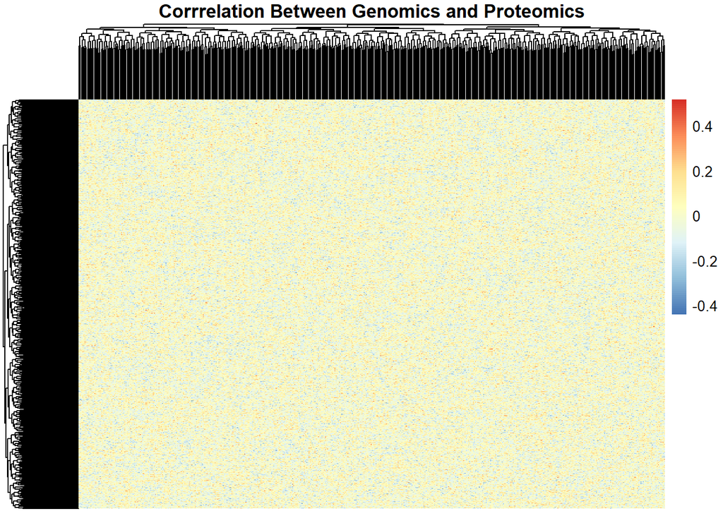

```r
# Heat map of correlations
pheatmap(correlation_matrix, main = "Corrrelation Between Genomics and Proteomics",
         clustering_distance_rows = "euclidean", clustering_distance_cols = "euclidean",
         show_rownames = FALSE, show_colnames = FALSE)
```

### 3. G. Interpretation of Results

By leveraging R and its extensive ecosystem, researchers can effectively analyze and visualize complex data, the field continues to evolve, the integration of multi-omics data will be invaluable in elucidating the complexities of diseases, paving the way for innovative therapeutic strategies.

### 3. H. Conclusion

In this book, “R for Bioinformatics: Analysis of Genomic and Biological Data,” we embarked on a journey through a fascinating intersection of R programming and the field of bioinformatics. Throughout the chapters, we explored the powerful capabilities of R as a tool for analyzing, visualizing and interpeting complex biological data, which has become increasingly important as genetic research continues to evolve rapidly.

We began with foundational concepts, ensuring that readers established a solid groundwork in both R programming and bioinformatics principles. From there, we delved into the specifics of data manipulation, exploring how to manage large datasets derived from genomics. We highlighted key packages such as “dplyr”, “tidyverse”, and “ggplot2” that facilitate data wrangling and visualization, helping you glean insights from intricate datasets.

As we progressed, we tackled the analysis of various types of biological data, including DNA sequences, RNA-Seq data and genomic variation. Through practical examples, we demonstrated how R can be leveraged to conduct differential expression analysis, variant calling and population genomic studies. The hands-on approaches outlined in this book aimed to equip you with practical skills to execute your analyses and interpret results effectively.

Moreover, we addressed the importance of reproducibility and documentation in bioinformatics research. By integrating tools such as RMarkdown and version control, you can ensure that your analyses are not only transparent but also replicable by others in the scientific community. This aspect of data science is vital in fostering collaboration and advancing knowledge in the field.

As bioinformatics continues to evolve, so will the tools and techniques available to us. We encourage you to remain engaged with the R community, explore new packages, and keep abreast of emerging technologies. Continuous learning and adaptation will be key as we navigate the complexities of biological data.

In summary, we hope this book serves as valuable resource for researchers, students and practitioners in bioinformatics. The applications of R in this domain are vast, and we believe that with the knowledge you’ve gained herein, you can tackle your own bioinformatics challenges and contribute meaningfully to our understanding of genomics and the biological sciences.

Thank you for joining us on this journey through R for bioinformatics. We look forward to seeing how you apply these insights to your own work and inspire further exploration in this exciting field

```r
Sys.Date()
```

```
## [1] "2026-01-18"
```